# Supervised Learning - Foundations Project: ReCell

## Problem Statement

### Business Context

Buying and selling used phones and tablets used to be something that happened on a handful of online marketplace sites. But the used and refurbished device market has grown considerably over the past decade, and a new IDC (International Data Corporation) forecast predicts that the used phone market would be worth \$52.7bn by 2023 with a compound annual growth rate (CAGR) of 13.6% from 2018 to 2023. This growth can be attributed to an uptick in demand for used phones and tablets that offer considerable savings compared with new models.

Refurbished and used devices continue to provide cost-effective alternatives to both consumers and businesses that are looking to save money when purchasing one. There are plenty of other benefits associated with the used device market. Used and refurbished devices can be sold with warranties and can also be insured with proof of purchase. Third-party vendors/platforms, such as Verizon, Amazon, etc., provide attractive offers to customers for refurbished devices. Maximizing the longevity of devices through second-hand trade also reduces their environmental impact and helps in recycling and reducing waste. The impact of the COVID-19 outbreak may further boost this segment as consumers cut back on discretionary spending and buy phones and tablets only for immediate needs.

### Objective

The rising potential of this comparatively under-the-radar market fuels the need for an ML-based solution to develop a dynamic pricing strategy for used and refurbished devices. ReCell, a startup aiming to tap the potential in this market, has hired you as a data scientist. They want you to analyze the data provided and build a linear regression model to predict the price of a used phone/tablet and identify factors that significantly influence it.

### Data Description

The data contains the different attributes of used/refurbished phones and tablets. The data was collected in the year 2021. The detailed data dictionary is given below.

- brand_name: Name of manufacturing brand
- os: OS on which the device runs
- screen_size: Size of the screen in cm
- 4g: Whether 4G is available or not
- 5g: Whether 5G is available or not
- main_camera_mp: Resolution of the rear camera in megapixels
- selfie_camera_mp: Resolution of the front camera in megapixels
- int_memory: Amount of internal memory (ROM) in GB
- ram: Amount of RAM in GB
- battery: Energy capacity of the device battery in mAh
- weight: Weight of the device in grams
- release_year: Year when the device model was released
- days_used: Number of days the used/refurbished device has been used
- normalized_new_price: Normalized price of a new device of the same model in euros
- normalized_used_price: Normalized price of the used/refurbished device in euros

## Importing necessary libraries

```python
# Libraries to help with reading and manipulating data
import numpy as np
import pandas as pd

# Libraries to help with data visualization
import matplotlib.pyplot as plt
import seaborn as sns

sns.set()

# split the data into train and test
from sklearn.model_selection import train_test_split

# to build linear regression_model
import statsmodels.api as sm

# Linear regression model
from sklearn.linear_model import LinearRegression

# to check model performance
from sklearn.metrics import mean_absolute_error, mean_squared_error, r2_score
```

## Loading the dataset

```python
data = pd.read_csv("/content/Dataset+-+User+Device+Data.csv")
```

## Data Overview

- Observations
- Sanity checks

```python
data.head()
```

|  | brand_name | os | screen_size | 4g | 5g | main_camera_mp | selfie_camera_mp | int_memory | ram | battery | weight | release_year | days_used | normalized_used_price | normalized_new_price |
| --- | --- | --- | --- | --- | --- | --- | --- | --- | --- | --- | --- | --- | --- | --- | --- |
| 0 | Honor | Android | 14.50 | yes | no | 13.0 | 5.0 | 64.0 | 3.0 | 3020.0 | 146.0 | 2020 | 127 | 4.307572 | 4.715100 |
| 1 | Honor | Android | 17.30 | yes | yes | 13.0 | 16.0 | 128.0 | 8.0 | 4300.0 | 213.0 | 2020 | 325 | 5.162097 | 5.519018 |
| 2 | Honor | Android | 16.69 | yes | yes | 13.0 | 8.0 | 128.0 | 8.0 | 4200.0 | 213.0 | 2020 | 162 | 5.111084 | 5.884631 |
| 3 | Honor | Android | 25.50 | yes | yes | 13.0 | 8.0 | 64.0 | 6.0 | 7250.0 | 480.0 | 2020 | 345 | 5.135387 | 5.630961 |
| 4 | Honor | Android | 15.32 | yes | no | 13.0 | 8.0 | 64.0 | 3.0 | 5000.0 | 185.0 | 2020 | 293 | 4.389995 | 4.947837 |

```python
data.shape
```

```
(3454, 15)
```

There are 15 attributes for 3454 observations

```python
data.info()
```

```
<class 'pandas.core.frame.DataFrame'>
RangeIndex: 3454 entries, 0 to 3453
Data columns (total 15 columns):
 #   Column                 Non-Null Count  Dtype
---  ------                 --------------  -----
 0   brand_name             3454 non-null   object
 1   os                     3454 non-null   object
 2   screen_size            3454 non-null   float64
 3   4g                     3454 non-null   object
 4   5g                     3454 non-null   object
 5   main_camera_mp         3275 non-null   float64
 6   selfie_camera_mp       3452 non-null   float64
 7   int_memory             3450 non-null   float64
 8   ram                    3450 non-null   float64
 9   battery                3448 non-null   float64
 10  weight                 3447 non-null   float64
 11  release_year           3454 non-null   int64
 12  days_used              3454 non-null   int64
 13  normalized_used_price  3454 non-null   float64
 14  normalized_new_price   3454 non-null   float64
dtypes: float64(9), int64(2), object(4)
memory usage: 404.9+ KB
```

brand name os 4g and 5g have to be converted to categorical values

```python
data.describe(include="all").T
```

|  | count | unique | top | freq | mean | std | min | 25% | 50% | 75% | max |
| --- | --- | --- | --- | --- | --- | --- | --- | --- | --- | --- | --- |
| brand_name | 3454 | 34 | Others | 502 | NaN | NaN | NaN | NaN | NaN | NaN | NaN |
| os | 3454 | 4 | Android | 3214 | NaN | NaN | NaN | NaN | NaN | NaN | NaN |
| screen_size | 3454.0 | NaN | NaN | NaN | 13.713115 | 3.80528 | 5.08 | 12.7 | 12.83 | 15.34 | 30.71 |
| 4g | 3454 | 2 | yes | 2335 | NaN | NaN | NaN | NaN | NaN | NaN | NaN |
| 5g | 3454 | 2 | no | 3302 | NaN | NaN | NaN | NaN | NaN | NaN | NaN |
| main_camera_mp | 3275.0 | NaN | NaN | NaN | 9.460208 | 4.815461 | 0.08 | 5.0 | 8.0 | 13.0 | 48.0 |
| selfie_camera_mp | 3452.0 | NaN | NaN | NaN | 6.554229 | 6.970372 | 0.0 | 2.0 | 5.0 | 8.0 | 32.0 |
| int_memory | 3450.0 | NaN | NaN | NaN | 54.573099 | 84.972371 | 0.01 | 16.0 | 32.0 | 64.0 | 1024.0 |
| ram | 3450.0 | NaN | NaN | NaN | 4.036122 | 1.365105 | 0.02 | 4.0 | 4.0 | 4.0 | 12.0 |
| battery | 3448.0 | NaN | NaN | NaN | 3133.402697 | 1299.682844 | 500.0 | 2100.0 | 3000.0 | 4000.0 | 9720.0 |
| weight | 3447.0 | NaN | NaN | NaN | 182.751871 | 88.413228 | 69.0 | 142.0 | 160.0 | 185.0 | 855.0 |
| release_year | 3454.0 | NaN | NaN | NaN | 2015.965258 | 2.298455 | 2013.0 | 2014.0 | 2015.5 | 2018.0 | 2020.0 |
| days_used | 3454.0 | NaN | NaN | NaN | 674.869716 | 248.580166 | 91.0 | 533.5 | 690.5 | 868.75 | 1094.0 |
| normalized_used_price | 3454.0 | NaN | NaN | NaN | 4.364712 | 0.588914 | 1.536867 | 4.033931 | 4.405133 | 4.7557 | 6.619433 |
| normalized_new_price | 3454.0 | NaN | NaN | NaN | 5.233107 | 0.683637 | 2.901422 | 4.790342 | 5.245892 | 5.673718 | 7.847841 |

```python
data.duplicated().sum()
```

```
0
```

There are no duplicate values

```python
data.isnull().sum()
```

```
brand_name                 0
os                         0
screen_size                0
4g                         0
5g                         0
main_camera_mp           179
selfie_camera_mp           2
int_memory                 4
ram                        4
battery                    6
weight                     7
release_year               0
days_used                  0
normalized_used_price      0
normalized_new_price       0
dtype: int64
```

there is a presence of null values

```python
# creating a copy of the data so that original data remains unchanged
df = data.copy()
```

```python
df.brand_name=df.brand_name.astype('category')
df.os = df.os.astype('category')
df['4g']=df['4g'].astype('category')
df['5g']=df['5g'].astype('category')
```

```python
df.describe(include="category").T
```

|  | count | unique | top | freq |
| --- | --- | --- | --- | --- |
| brand_name | 3454 | 34 | Others | 502 |
| os | 3454 | 4 | Android | 3214 |
| 4g | 3454 | 2 | yes | 2335 |
| 5g | 3454 | 2 | no | 3302 |

## Exploratory Data Analysis (EDA)

- EDA is an important part of any project involving data.
- It is important to investigate and understand the data better before building a model with it.
- A few questions have been mentioned below which will help you approach the analysis in the right manner and generate insights from the data.
- A thorough analysis of the data, in addition to the questions mentioned below, should be done.

**Questions**:

1. What does the distribution of normalized used device prices look like?
2. What percentage of the used device market is dominated by Android devices?
3. The amount of RAM is important for the smooth functioning of a device. How does the amount of RAM vary with the brand?
4. A large battery often increases a device's weight, making it feel uncomfortable in the hands. How does the weight vary for phones and tablets offering large batteries (more than 4500 mAh)?
5. Bigger screens are desirable for entertainment purposes as they offer a better viewing experience. How many phones and tablets are available across different brands with a screen size larger than 6 inches?
6. A lot of devices nowadays offer great selfie cameras, allowing us to capture our favorite moments with loved ones. What is the distribution of devices offering greater than 8MP selfie cameras across brands?
7. Which attributes are highly correlated with the normalized price of a used device?

EDA for numerical variables.

```python
df1=df.copy()
```

```python
def histogram_boxplot(data, feature, figsize=(15, 10), kde=False, bins=None):
    """
    Boxplot and histogram combined

    data: dataframe
    feature: dataframe column
    figsize: size of figure (default (15,10))
    kde: whether to show the density curve (default False)
    bins: number of bins for histogram (default None)
    """
    f2, (ax_box2, ax_hist2) = plt.subplots(
        nrows=2,  # Number of rows of the subplot grid= 2
        sharex=True,  # x-axis will be shared among all subplots
        gridspec_kw={"height_ratios": (0.25, 0.75)},
        figsize=figsize,
    )  # creating the 2 subplots
    sns.boxplot(
        data=data, x=feature, ax=ax_box2, showmeans=True, color="violet"
    )  # boxplot will be created and a triangle will indicate the mean value of the column
    sns.histplot(
        data=data, x=feature, kde=kde, ax=ax_hist2, bins=bins
    ) if bins else sns.histplot(
        data=data, x=feature, kde=kde, ax=ax_hist2
    )  # For histogram
    ax_hist2.axvline(
        data[feature].mean(), color="red", linestyle="--"
    )  # Add mean to the histogram
    ax_hist2.axvline(
        data[feature].median(), color="blue", linestyle="-"
    )  # Add median to the histogram
```

```python
def labeled_barplot(data, feature, perc=False, n=None):
    """
    Barplot with percentage at the top

    data: dataframe
    feature: dataframe column
    perc: whether to display percentages instead of count (default is False)
    n: displays the top n category levels (default is None, i.e., display all levels)
    """

    total = len(data[feature])  # length of the column
    count = data[feature].nunique()
    if n is None:
        plt.figure(figsize=(count + 2, 6))
    else:
        plt.figure(figsize=(n + 2, 6))

    plt.xticks(rotation=90, fontsize=15)
    ax = sns.countplot(
        data=data,
        x=feature,
        palette="Paired",
        order=data[feature].value_counts().index[:n],
    )

    for p in ax.patches:
        if perc == True:
            label = "{:.1f}%".format(
                100 * p.get_height() / total
            )  # percentage of each class of the category
        else:
            label = p.get_height()  # count of each level of the category

        x = p.get_x() + p.get_width() / 2  # width of the plot
        y = p.get_height()  # height of the plot

        ax.annotate(
            label,
            (x, y),
            ha="center",
            va="center",
            size=12,
            xytext=(0, 5),
            textcoords="offset points",
        )  # annotate the percentage

    plt.show()  # show the plot
```

# Q1.What does the distribution of normalized used device prices look like?

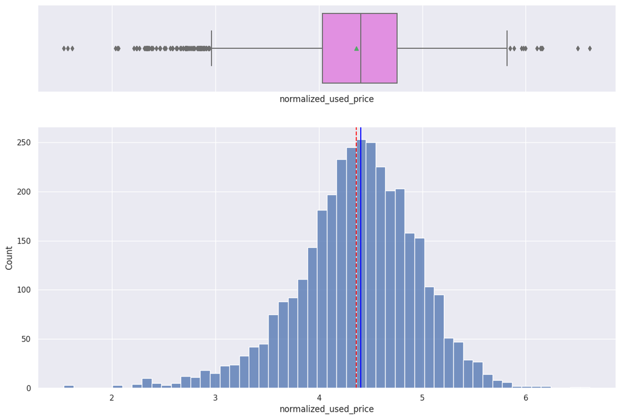

```python
histogram_boxplot(df1, "normalized_used_price")
```

Median is slightly more than mean,it is slightly left skewed(almost normally distributed), looks like there is a presence of outliers.The average price of used devices is 4.364712

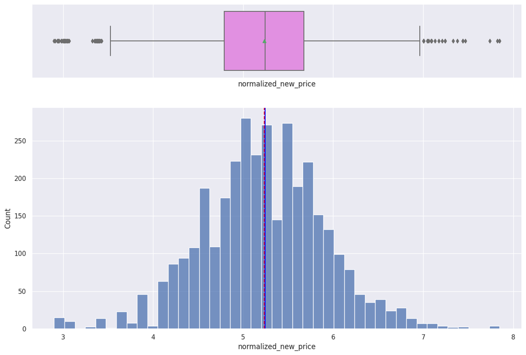

```python
histogram_boxplot(df1, "normalized_new_price") # New price_column
```

The data is almost normally distributed however, there is a presence of many outliers.

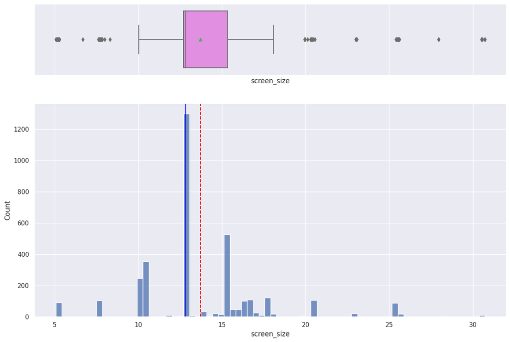

```python
histogram_boxplot(df1, "screen_size") # screensize column
```

The data is not normally distributed and the curve is highly skewed on both the sides.

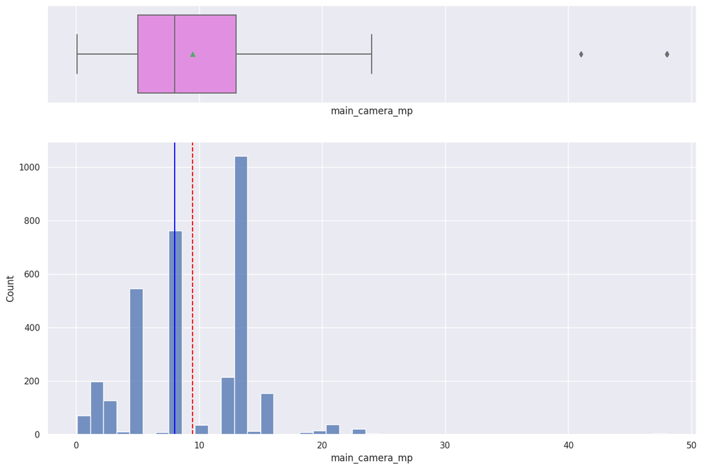

```python
histogram_boxplot(df1, "main_camera_mp") # hist_boxplot of main_camera_mp column
```

The data is not normally distributed and the curve is highly skewed on both the sides.main_camera_mp has 2 outliers and the distribution is not normal. Average main camera mp is around 9 MP.

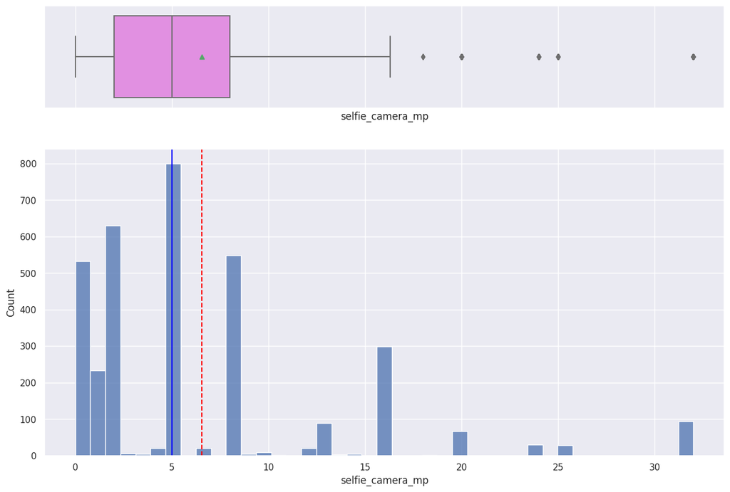

```python
histogram_boxplot(df1, "selfie_camera_mp") # plotting selfie_camera_mp column
```

The distribution of the selfie camera_mp is not normal and it has few outliers on the right side. Avg. MP of the selfie camera is 6.5.

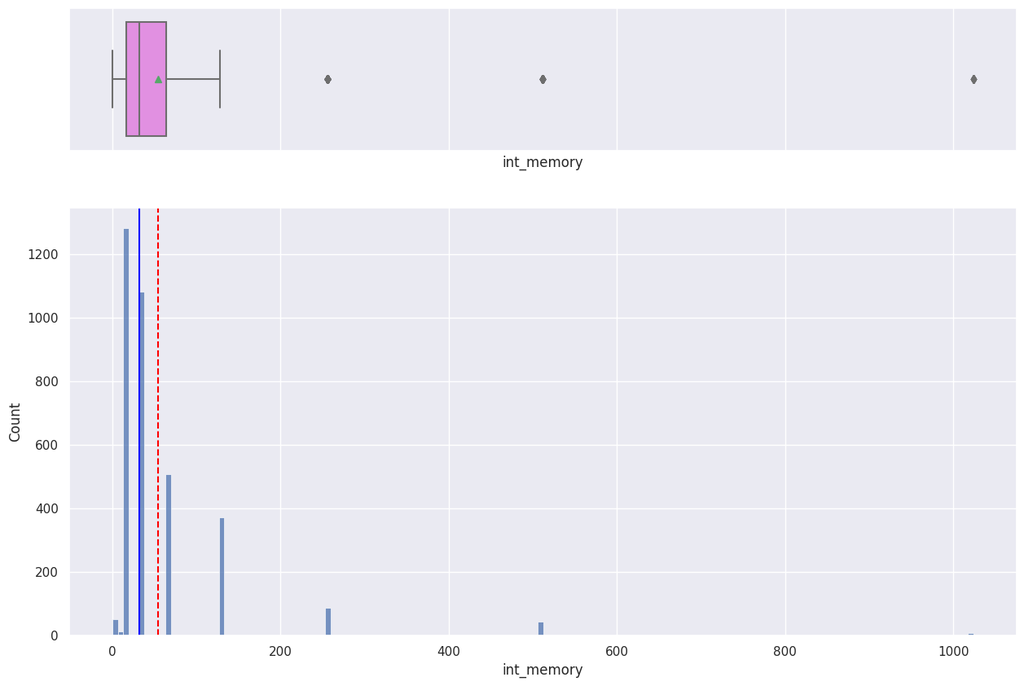

```python
histogram_boxplot(df1, "int_memory") # plotting of int_memory column
```

The internal memory variable exhibits some outliers on the higher end of the spectrum. The distribution deviates from normality, and the average internal memory size is approximately 50 gigabytes

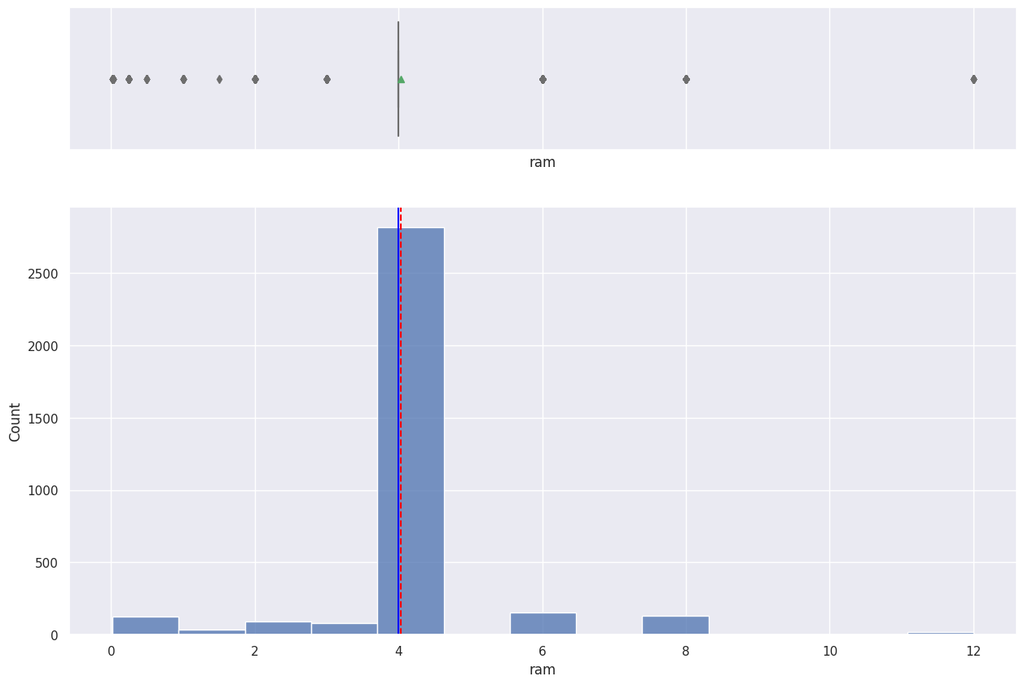

```python
histogram_boxplot(df, "ram") # his_box plot of "ram" column
```

The "RAM" attribute contains numerous outliers, and its distribution is not Gaussian. The average RAM size is 4 gigabytes, with the mean and median situated at the same level.

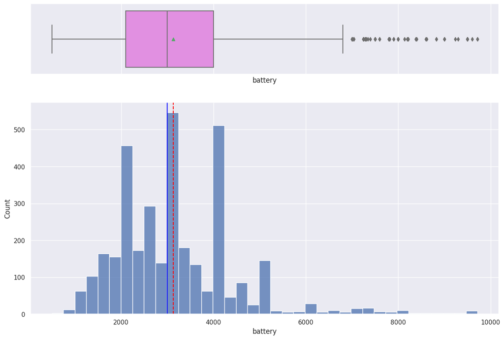

```python
histogram_boxplot(df, "battery") # hist_box plot "battery" column
```

The "Battery" attribute displays outliers, and its distribution is not normal, showing a significant right skewness. The average battery capacity is approximately 3200 milliampere-hours (mAh).

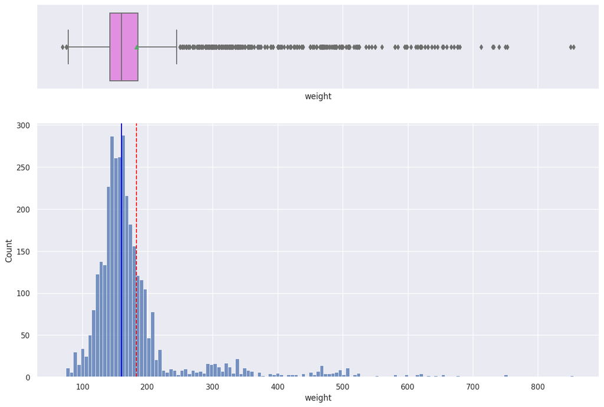

```python
histogram_boxplot(df, "weight") # hist_box plot of "weight" column.
```

The "weight" characteristic exhibits numerous outliers on the right side. While the distribution somewhat adheres to a normal distribution, it is notably right-skewed. The average weight of the phone is approximately 190 grams.

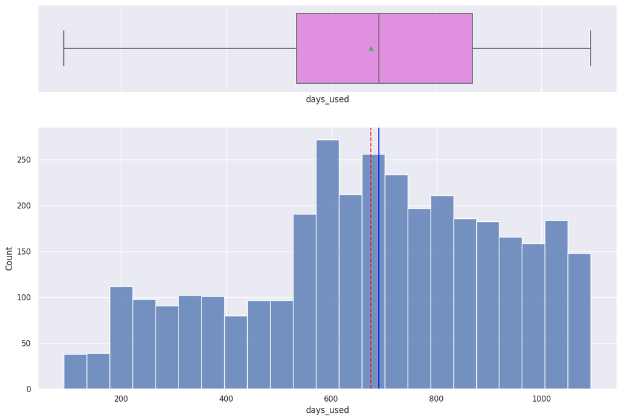

```python
histogram_boxplot(df, "days_used") # hist_box plot of days_used column
```

The "days_used" feature lacks outliers in its distribution. However, the distribution itself is not normal. On average, the number of days used is approximately 670 days.

# EDA for categorical variables

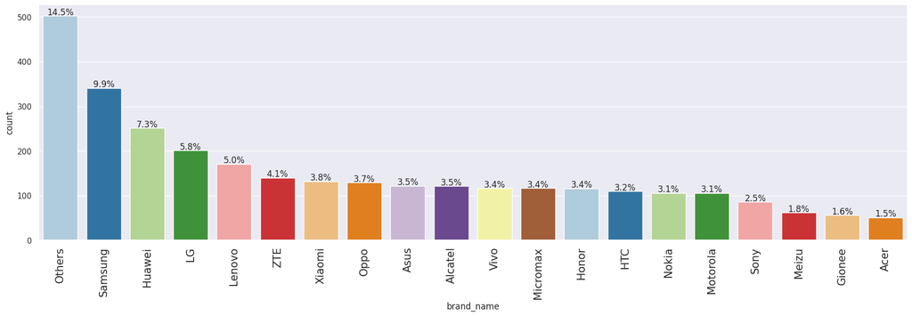

```python
labeled_barplot(df1, "brand_name", perc=True, n=20) # labeled bar plot for "brand_name"
```

Others occupies the highest concentration of used phones. Samsung is the most popular well known brand in used phones market

# Q2 What percentage of the used device market is dominated by Android devices?

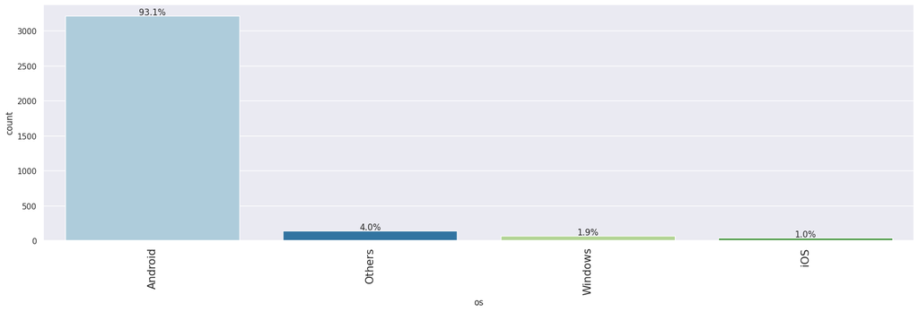

```python
labeled_barplot(df1, "os", perc=True, n=20) # labeled bar plot for "brand_name"
```

Q2. Android phones occupy 93.1% of the market.

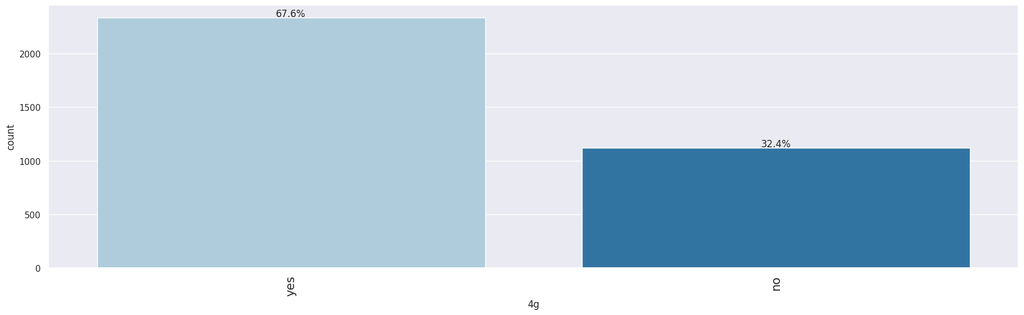

```python
labeled_barplot(df1, "4g", perc=True, n=20) # labeled bar plot for "brand_name"
```

67.6% phones have 4g

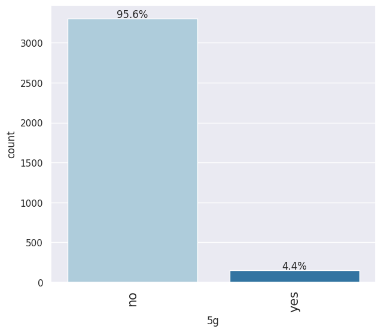

```python
labeled_barplot(df1, "5g", perc=True, n=5) # labelled bar plot for "5g"
```

only 4.4% phones have 5g

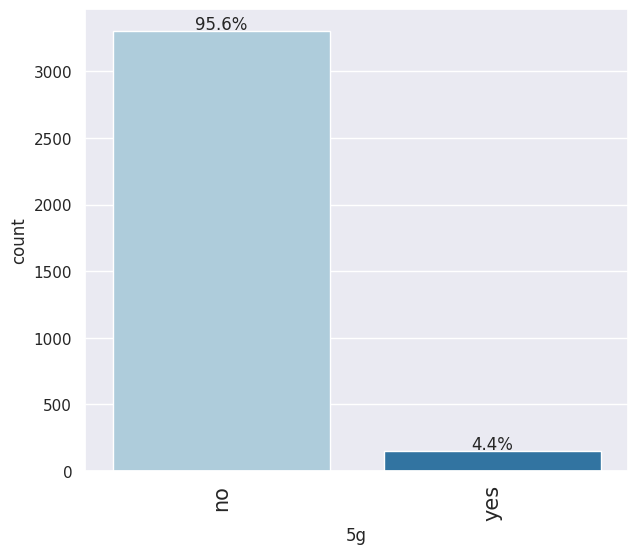

```python
labeled_barplot(df, "5g", perc=True, n=5) # labelled bar plot for "5g"
```

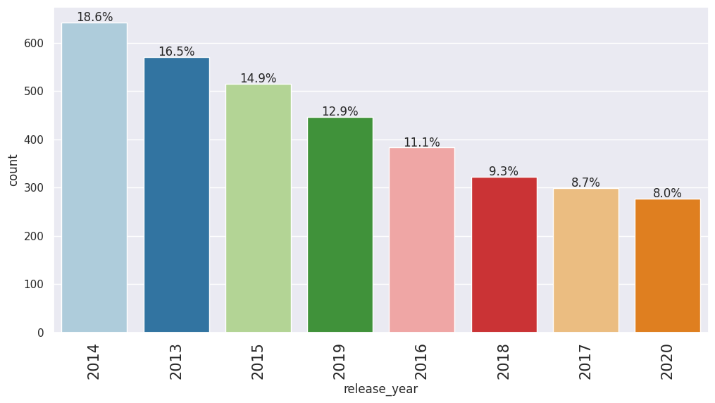

```python
labeled_barplot(df, "release_year", perc=True, n=10) # labelled bar plot for release_year
```

most phones released in the year 2014

```python
# creating a list of numerical columns
num_cols = df.select_dtypes(include=np.number).columns.tolist()

# dropping start and finish year from list of numerical columns as they are not numerical in nature
num_cols.remove("release_year")
```

1. Which attributes are highly correlated with the normalized price of a used device?

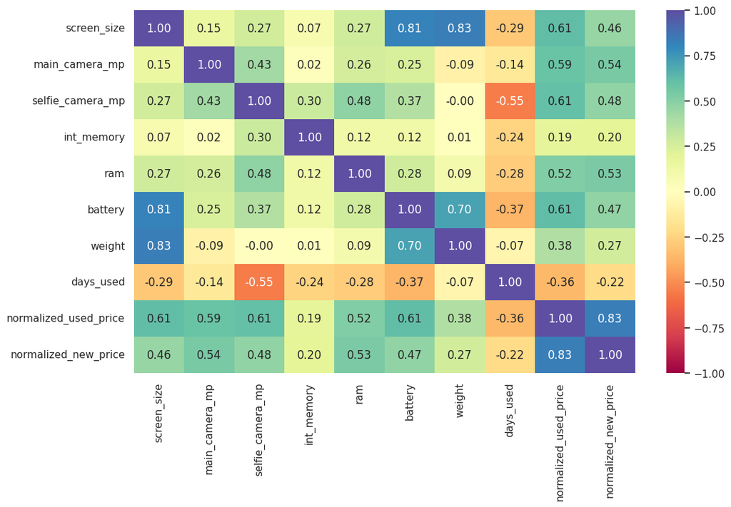

```python
plt.figure(figsize=(12, 7))
sns.heatmap(
    df[num_cols].corr(), annot=True, vmin=-1, vmax=1, fmt=".2f", cmap="Spectral"
)
plt.show()
```

- **Strong positive correlations:** screen_size, main_camera_mp, selfie_camera_mp, ram, battery, normalized_new_price
- **Weak positive correlations:** int_memory, weight
- **Weak negative correlation:** days_used

This suggests that normalized_used_price is generally higher for cell phones with larger screens, better cameras, more memory, and longer battery life. It is also generally higher for cell phones that are newer.

It is important to note that correlation does not equal causation. Just because two variables are correlated does not mean that one causes the other. However, the correlations observed in the correlation matrix suggest that there is some relationship between normalized_used_price and the other variables.

# Q 3. The amount of RAM is important for the smooth functioning of a device. How does the amount of RAM vary with the brand?

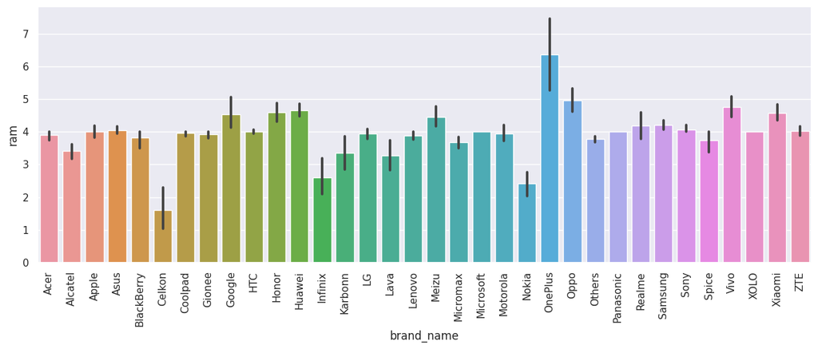

```python
plt.figure(figsize=(15, 5))

sns.barplot(x='brand_name',y='ram',data=df1)
plt.xticks(rotation=90)
plt.show()
```

# Q4.A large battery often increases a device's weight, making it feel uncomfortable in the hands. How does the weight vary for phones and tablets offering large batteries (more than 4500 mAh)?

```python
df_big_battery=df[df.battery > 4500]
```

```python
df_big_battery.groupby('brand_name')["weight"].mean().sort_values(ascending=False)
```

```
brand_name
Google        517.000000
Lenovo        442.721429
Apple         439.558824
Sony          439.500000
HTC           425.000000
Samsung       398.352000
Huawei        394.486486
Others        390.546341
Alcatel       380.000000
LG            366.058333
Acer          360.000000
Nokia         318.000000
Asus          313.772727
Honor         248.714286
Xiaomi        231.500000
Gionee        209.430000
Motorola      200.757143
Realme        196.833333
Vivo          195.630769
ZTE           195.400000
Oppo          195.000000
Infinix       193.000000
Panasonic     182.000000
Spice         158.000000
Micromax      118.000000
BlackBerry           NaN
Celkon               NaN
Coolpad              NaN
Karbonn              NaN
Lava                 NaN
Meizu                NaN
Microsoft            NaN
OnePlus              NaN
XOLO                 NaN
Name: weight, dtype: float64
```

Google phones with battery greater than 4500 mah are the heaviest, micromax phones of the same kind are the lightest

```python
df_big_battery['brand_name'].isnull()
```

```
3       False
4       False
11      False
19      False
20      False
        ...
3420    False
3421    False
3434    False
3448    False
3449    False
Name: brand_name, Length: 341, dtype: bool
```

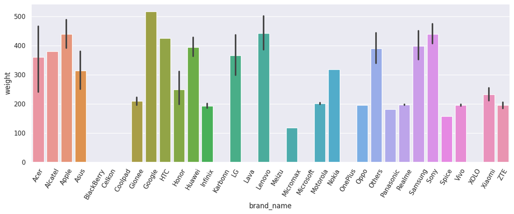

```python
plt.figure(figsize=(15, 5))
sns.barplot(x='brand_name',y='weight',data=df_big_battery)
plt.xticks(rotation=60)
plt.show()
```

# Q5. Bigger screens are desirable for entertainment purposes as they offer a better viewing experience. How many phones and tablets are available across different brands with a screen size larger than 6 inches?

```python
df_big_screen=df[df.screen_size>6*2.54]
df_big_screen.groupby('brand_name')['screen_size'].count().sort_values(ascending=False)
```

```
brand_name
Huawei        149
Samsung       119
Others         99
Vivo           80
Honor          72
Oppo           70
Lenovo         69
Xiaomi         69
LG             59
Motorola       42
Asus           41
Realme         40
Alcatel        26
Apple          24
Acer           19
Meizu          17
ZTE            17
OnePlus        16
Nokia          15
Sony           12
Infinix        10
Micromax        7
HTC             7
Google          4
XOLO            3
Gionee          3
Coolpad         3
Spice           2
Panasonic       2
Karbonn         2
Microsoft       1
Celkon          0
BlackBerry      0
Lava            0
Name: screen_size, dtype: int64
```

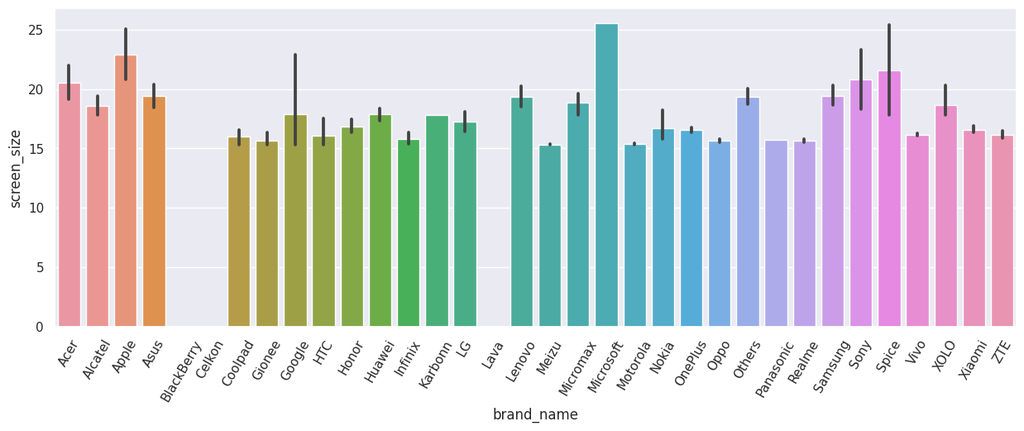

```python
plt.figure(figsize=(15, 5))
sns.barplot(x='brand_name',y='screen_size',data=df_big_screen)
plt.xticks(rotation=60)
plt.show()
```

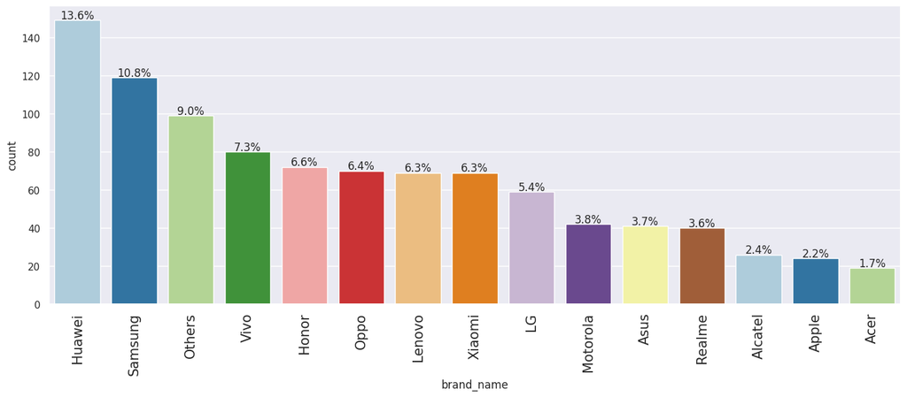

```python
labeled_barplot(df_big_screen,"brand_name",perc=True,n=15)
```

# Q6.A lot of devices nowadays offer great selfie cameras, allowing us to capture our favorite moments with loved ones. What is the distribution of devices offering greater than 8MP selfie cameras across brands?

```python
df_good_selfiecam= df[df.selfie_camera_mp>8]
df_good_selfiecam.groupby('brand_name')['selfie_camera_mp'].count().sort_values(ascending=False)
```

```
brand_name
Huawei        87
Vivo          78
Oppo          75
Xiaomi        63
Samsung       57
Honor         41
Others        34
LG            32
Motorola      26
Meizu         24
ZTE           20
HTC           20
Realme        18
OnePlus       18
Sony          14
Lenovo        14
Nokia         10
Asus           6
Gionee         4
Infinix        4
Coolpad        3
Micromax       2
Panasonic      2
BlackBerry     2
Acer           1
Apple          0
XOLO           0
Spice          0
Google         0
Karbonn        0
Lava           0
Microsoft      0
Alcatel        0
Celkon         0
Name: selfie_camera_mp, dtype: int64
```

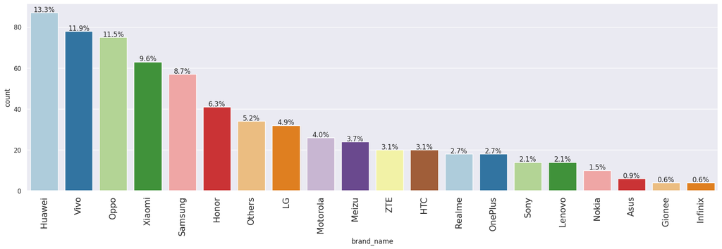

```python
labeled_barplot(df_good_selfiecam, "brand_name", perc=True, n=20) # plotting the least used devise using bar_plot
```

13.3% of phones with good selfie camera are huaweis

## Data Preprocessing

- Missing value treatment
- Feature engineering (if needed)
- Outlier detection and treatment (if needed)
- Preparing data for modeling
- Any other preprocessing steps (if needed)